# **Factors influencing Scots’ satisfaction with public transport**

Group 28: Aishwin Tikku, Mengran Li, Steven Kwok, Shaoquan Li, Shuning Li

# Introduction

Public transport is necessary for most Scottish people. Therefore, its comfort and customer satisfaction are important for operators. To help improve public transport, The purpose is to discover factors having correlation with passengers’ satisfaction in this project. The data are from Scotland’s official statistics. The theme of Transport contains seven data sets, Road Transport Expenditure, Public Transport, Road Vehicles, Concessionary Travel Cards, Road Network and Traffic, Travel to Work and Other Purposes. There are 460 observations of 24 variables in this research.Find the best results through “Model diagnosis” , “stepwise regression” and comparing the selected model with full model on $adj$ $R^2$, AIC and BIC.

# Exploratory Data Analysis

The whole data set, combined from seven data sets obtained from website of Scottish government statistics, has 24 factors and 460 observations. The explanatory variables are Road Casualties, Road Transport Expenditure, Public Transport, Road Vehicles, Concessionary Travel Cards, Road Network and Traffic and Travel to work and other purposes.

Firstly, filter and merge data.

```r
#### data wrangling ####

# select total number of casualty outcomes
Casualties <- Casualties %>%
  select(-c(Measurement, Units)) %>%
  filter(Outcome == "Killed Or Seriously Injured") %>%
  spread(Outcome, Value) %>%
  filter(Age == "All" & Gender == "All") %>%
  select(-c(Age, Gender))

# rename variable name
Expenditure <- Expenditure %>%
  select(-c(Measurement, Units)) %>%
  rename(Expenditure = Value)

# remove variables at the whole Scotland level
Transport <- Transport %>%
  select(-c(Measurement, Units)) %>%
  filter(`Indicator (public transport)` %in% c(
    "Number Of Passenger Train Stations",
    "Percentage Of Adults Reporting that they are Very or Fairly Satisfied with Public Transport"
  )) %>%
  spread(`Indicator (public transport)`, Value)

Vehicles <- Vehicles %>%
  select(-c(Measurement, Units)) %>%
  spread(`Indicator (road vehicles)`, Value)

# retain card numbers of all people
Cards <- Cards %>%
  select(-c(Measurement, Units)) %>%
  spread(Age, Value) %>%
  select(-`60 years and over`) %>%
  rename(Cards = All)

Network <- Network %>%
  select(-c(Measurement, Units)) %>%
  spread(`Indicator (road network traffic)`, Value)

Purposes <- Purposes %>%
  select(-c(Measurement, Units)) %>%
  spread(`Indicator (travel to work)`, Value)

# merge all dataset into one complete dataset by 'FeatureCode' and 'DateCode'
Data <- Expenditure %>%
  left_join(Casualties,
    by = c(
      "FeatureCode" = "FeatureCode",
      "DateCode" = "DateCode"
    )
  ) %>%
  left_join(Cards,
    by = c(
      "FeatureCode" = "FeatureCode",
      "DateCode" = "DateCode"
    )
  ) %>%
  left_join(Network,
    by = c(
      "FeatureCode" = "FeatureCode",
      "DateCode" = "DateCode"
    )
  ) %>%
  left_join(Purposes,
    by = c(
      "FeatureCode" = "FeatureCode",
      "DateCode" = "DateCode"
    )
  ) %>%
  left_join(Transport,
    by = c(
      "FeatureCode" = "FeatureCode",
      "DateCode" = "DateCode"
    )
  ) %>%
  left_join(Vehicles,
    by = c(
      "FeatureCode" = "FeatureCode",
      "DateCode" = "DateCode"
    )
  )

# rename variables
names(Data) <- c(
  "FeatureCode", "DateCode", "Expenditure", "Killed_Injured",
  "Cards", "Congestion", "Repair", "Mileage", "Work_Bus",
  "Business", "School", "Commuting", "Work_Cycling", "Education",
  "Health", "Shopping", "Work_Train", "Work_Walking", "Train_Stations",
  "Satisfaction", "One_Car", "More_Car", "Without_Car", "Petrol_Diesel"
)

# Transform the DateCode as a factor
Data$DateCode <- as.factor(Data$DateCode)
```

Secondly, we get a complete data set called Data, and summarize density plots are illustrated to detect data patterns.

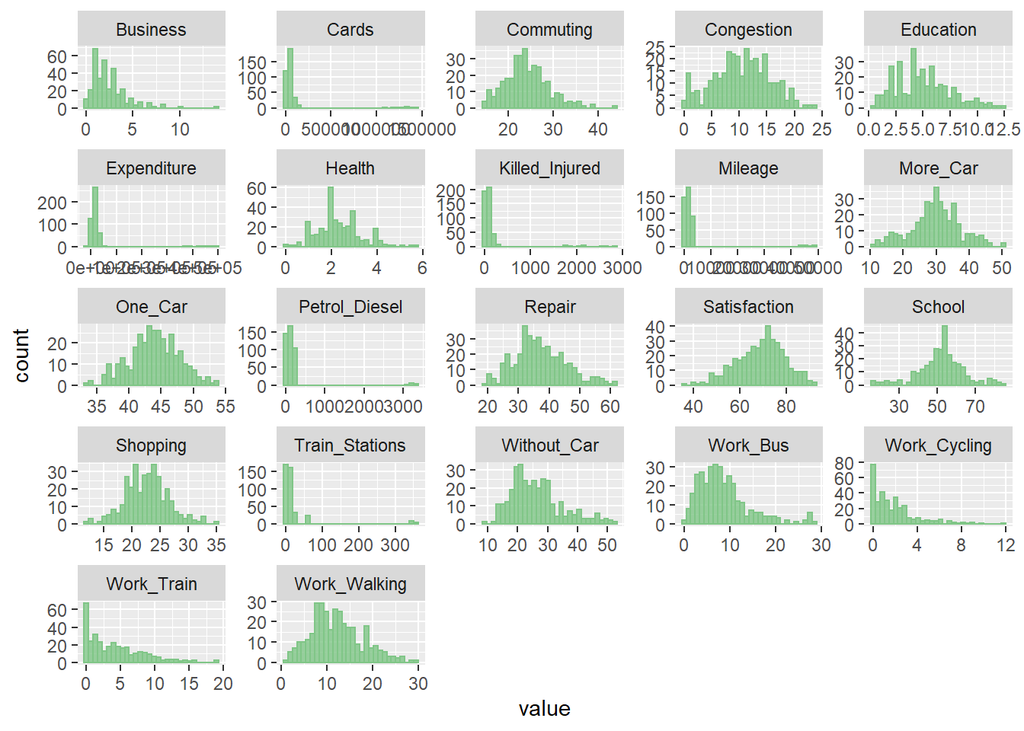

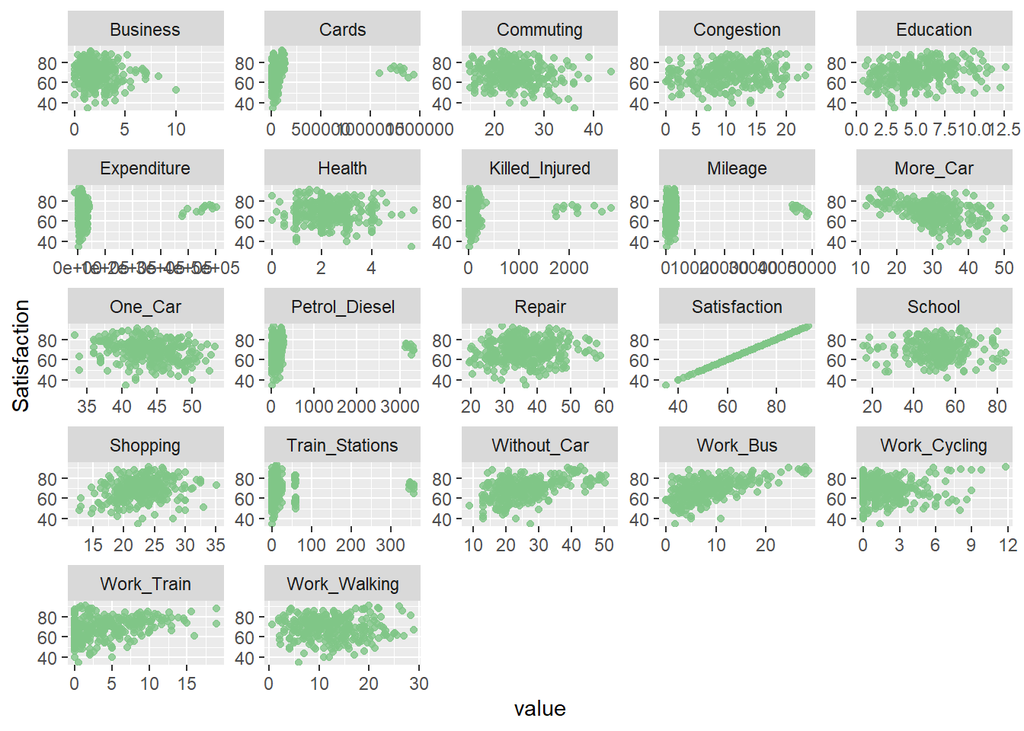

The scatter and correlation plots are proposed to explore the relationship among variables.

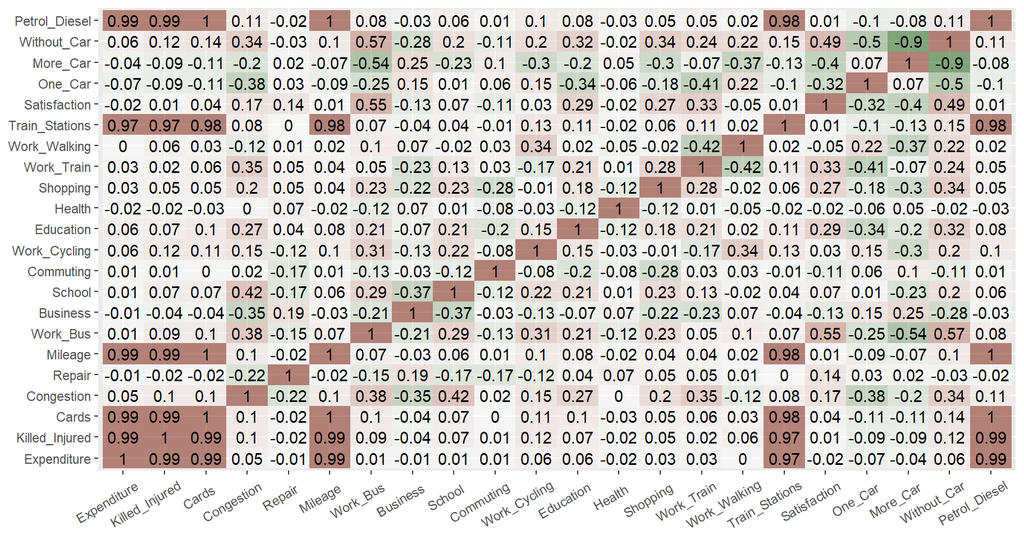

Through the correlation plot, there is a strong linear relationship between “Petrol_Diesel” “Train_Stations”, “Mileage”, “Expenditure”, “Killed_Injured” and “Cards”. Then we analyse the regression diagnosis results of model1 with all variables

```r
#### linear regression ####
# full model
fit <- lm(Satisfaction ~ ., data = na.omit(Data[, -1]))
```

Plot the Fitted values against Residuals and Q-Q plot to assess our assumptions.

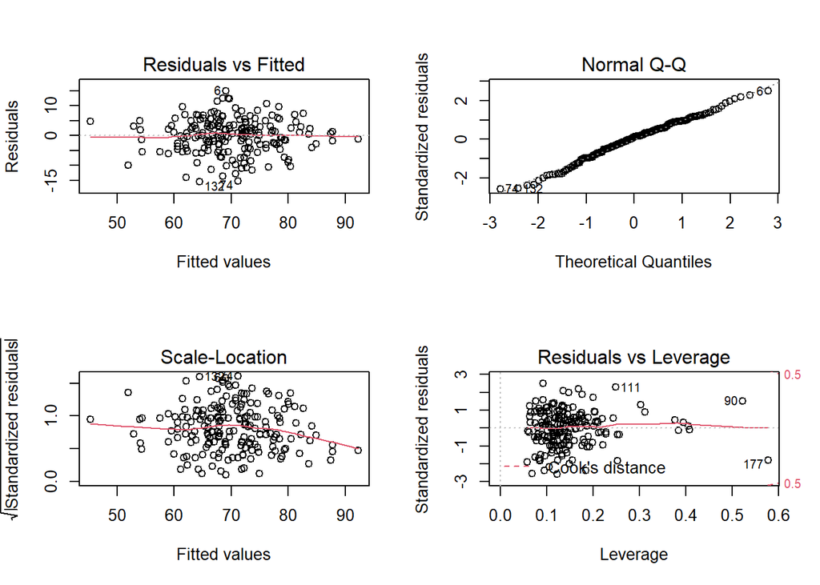

# Formal Data Analysis

Linear regression model, a model for examining and discovering relations between the response variable and explanatory variable(s), is applied in this project. The Satisfaction is the response variable, the DateCode is the control variable and others are independent variables. A linear regression model is applied as:
$$y=\beta_0+\beta_1x_1+\dots+\beta_px_p+\varepsilon$$
where y is the response variable, $x_1$ to $x_p$ is the number of columns selected from 1 to p, $\beta_0$ is the intercept of data, $\beta_1$ to $\beta_p$ is the coefficients of corresponding columns of X from 1 to p. The $ε$ is the error terms of the estimations.

```r
#library(MASS)
library(MASS)
stepAIC(fit, na.rm = TRUE)

# 3 4 5 8 24
# cards, killed_injured, expenditure, petrol_diesel, mileage are highly correlated.
# model 2 without
names(Data)[c(3, 4, 5, 8, 24)]

fit2 <- lm(Satisfaction ~ DateCode + Cards + Repair + Work_Bus +
             School + Health + Work_Train + Train_Stations + Without_Car +
             Petrol_Diesel, data = na.omit(Data[, -1]))
summary(fit2)

#### Model selection ####

glance(fit)
glance(fit2)
```

Table.1: Model2, selected by Stepwise regression

| term | estimate | std.error | statistic | p.value |
| --- | --- | --- | --- | --- |
| (Intercept) | 52.9775625 | 3.9466689 | 13.4233613 | 0.0000000 |
| Cards | 0.0001289 | 0.0000352 | 3.6559946 | 0.0003356 |
| Repair | 0.2494980 | 0.0665578 | 3.7485909 | 0.0002391 |
| Work_Bus | 0.7333901 | 0.1074918 | 6.8227543 | 0.0000000 |
| School | -0.1207559 | 0.0485715 | -2.4861470 | 0.0138198 |
| Health | 0.2824925 | 0.5313962 | 0.5316043 | 0.5956519 |
| Work_Train | 0.7066629 | 0.1314720 | 5.3750078 | 0.0000002 |
| Train_Stations | -0.1537078 | 0.0468778 | -3.2789066 | 0.0012497 |
| Without_Car | 0.1676106 | 0.0740901 | 2.2622533 | 0.0248705 |
| Petrol_Diesel | -0.0367942 | 0.0146720 | -2.5077725 | 0.0130293 |

Table.2: Comparison of model1 with model2 on adj R2, AIC and BIC

| model | adj.r.squared | AIC | BIC |
| --- | --- | --- | --- |
| model 1 | 0.5478475 | 1271.288 | 1365.604 |
| model 2 | 0.4998739 | 1274.555 | 1310.330 |

To obtain robust results, using Bootstrap to select significant variables at 95% level and obtain its confidence interval of parameter estimation and their observations.This process should be repeated 1000 times.

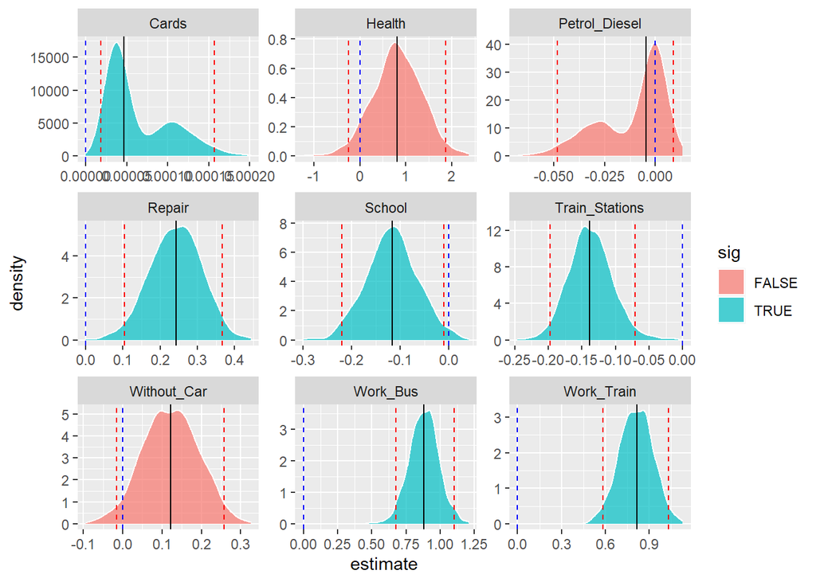

Density plots of parameters via bootstrap

The density plots of parameters are displayed. The variables with orange are not significant while the variables with blue are significant at the $\alpha=0.05$. The blue dashed lines are zero and the orange dashed lines are 95% CI of parameters.

# Conclusions

- The variables Cards (Number of concessionary cards issued to all adults), Repair (The Percentage of Roads Needing Repairs), Work_Bus (Bus Journeys To Work) and Work_Train (Train Journeys To Work) have positive influence on satisfaction with public transport. The School (Child Journeys To School By Walking/Cycling) and Train_Stations (Number of Train Stations) have negative relationship with satisfaction with public transport.
- The reason that more roads needing repairs and less train stations come with higher satisfaction needs to be further explored.

# References

- Jim Hester and Hadley Wickham, (2020). *fs: Cross-Platform File System Operations Based on ‘libuv’.* R package version 1.5.0
- Kuhn et al., (2020). *Tidymodels: a collection of packages for modeling and machine learning using tidyverse principles*.
- Wickham et al., (2019). *Welcome to the tidyverse. Journal of Open Source Software*, e, 4(43), 1686